# EP04-equipo-8

2025-09-05

#### *Contexto: En una planta química hay dos máquinas que envasan detergentes industriales en bidones con un volumen de producto que sigue una distribución normal con desviación estándar de 1 litro. La ingeniera a cargo de la planta debe asegurar que los bidones se están llenando con una media de 10 litros. Pero ella tiene la sospecha de que hay desviaciones en esta media, lo que piensa confirmar usando una muestra aleatoria de 100 envases (50 de cada una de las máquinas). También cree que hay diferencia en el cumplimiento del volumen requerido entre la máquina más antigua y la más moderna, que han de andar por el 90% y 96% de los bidones, respectivamente.*

##### **Pregunta 1: Si la ingeniera está seguro de que el verdadero volumen medio no puede ser inferior a 10 litros y piensa rechazar la hipótesis nula cuando la muestra presente una media mayor a 10,2 litros, ¿cuál es la probabilidad de que cometa un error de tipo I? Para responder, generen un gráfico de la distribución muestral de las medias hipotetizada en donde se marque la zona correspondiente a la probabilidad solicitada, para luego, basándose en este gráfico, calcular el área correspondiente. Tome como ejemplo los scripts presentados en la lectura sobre poder estadístico.**

Para poder responder cual es la probabilidad de que la ingeniera cometa un error de tipo I, estableceremos las suiguientes hipótesis:

$$\text{Hipótesis nula}\ (H_0) \text{ : la media poblacional de los
bidones es igual a 10 litros.}\ (\mu = 10)\\
\text{Hipótesis alternativa}\ (H_A) \text{ : la media poblacional es
mayor a 10 litros.}\ (\mu > 10)$$

```r
library(ggplot2)

mu0   <- 10
sigma <- 1
n     <- 100
SE    <- sigma / sqrt(n)
corte <- 10.2

alpha <- 1 - pnorm((corte - mu0) / SE)
alpha
```

```
## [1] 0.02275013
```

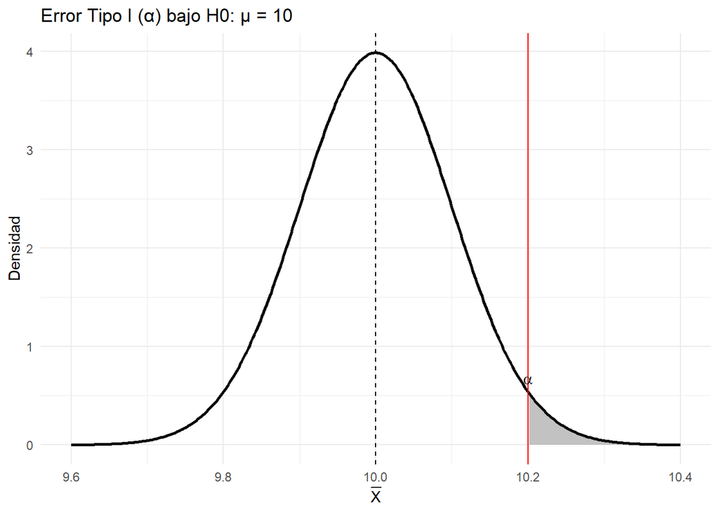

```r
xs <- seq(mu0 - 4*SE, mu0 + 4*SE, length.out = 400)
df <- data.frame(x = xs, y = dnorm(xs, mean = mu0, sd = SE))

g <- ggplot(df, aes(x, y)) +
  geom_line(linewidth = 0.9) +
  geom_area(data = subset(df, x >= corte), aes(y = y), alpha = 0.3) +
  geom_vline(xintercept = mu0, linetype = 2) +
  geom_vline(xintercept = corte, color = "red") +
  annotate("text", x = corte, y = dnorm(corte, mu0, SE),
           label = expression(alpha), vjust = -1) +
  labs(title = "Error Tipo I (α) bajo H0: μ = 10", y = "Densidad") +
  scale_x_continuous(name = expression(bar(X))) +
  theme_minimal()

print(g)
```

La probabilidad de cometer un error de tipo I, es decir, rechazar la hipótesis nula cuando en realidad la media poblacional es 10 litros, corresponde al área en la cola derecha de la distribución bajo H0 para valores mayores a 10,2. El cálculo entrega $\alpha \approx 0.0228$, lo que significa que existe alrededor de un 2,3% de riesgo de concluir erróneamente que los bidones no cumplen con el volumen esperado.

##### **Pregunta 2: Si el verdadero volumen medio de los bidones fuera de 10,1 litros, ¿cuál sería la probabilidad de que la ingeniera, que obviamente no conoce este dato, cometa un error de tipo II? Para responder, agregue al gráfico anterior la verdadera distribución muestral de las medias y marquen (con otro color) la zona correspondiente a la probabilidad solicitada, para luego, basándose en este gráfico, calcular el área correspondiente. También hay ejemplos de este procedimiento en la lectura sobre poder estadístico.**

Para esta pregunta, se establecen las siguientes hipotesis:

$$\text{Hipótesis nula}\ (H_0) \text{ : la media poblacional de los
bidones es igual a 10 litros.}\ (\mu = 10)\\
\text{Hipótesis alternativa}\ (H_A) \text{ : la media poblacional es
mayor a 10 litros, en particular 10,1 L en este caso.}\ (\mu > 10)$$

```r
mu1   <- 10.1
beta  <- pnorm((corte - mu1) / SE)
poder <- 1 - beta
beta; poder
```

```
## [1] 0.8413447
```

```
## [1] 0.1586553
```

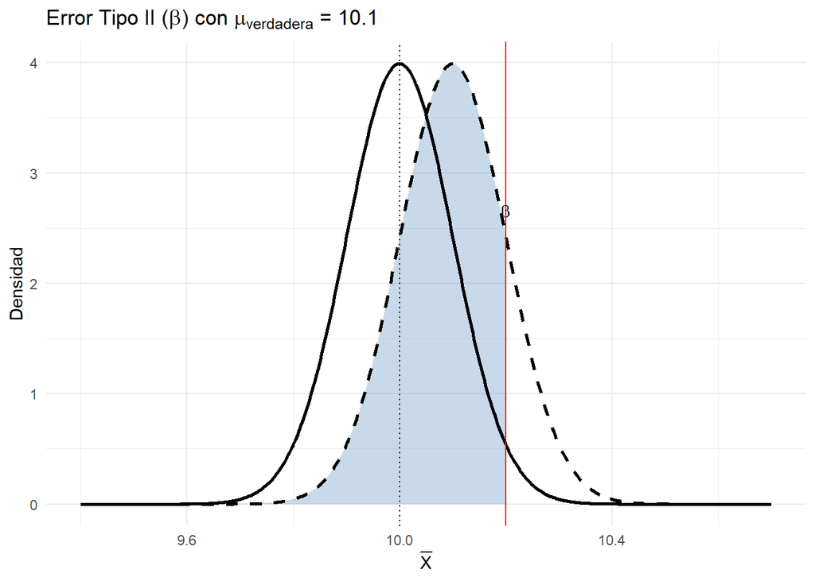

```r
xs <- seq(mu0 - 6*SE, mu1 + 6*SE, length.out = 600)
df <- data.frame(
  x   = xs,
  dH0 = dnorm(xs, mean = mu0, sd = SE),
  dH1 = dnorm(xs, mean = mu1, sd = SE)
)

g2 <- ggplot(df, aes(x)) +
  geom_area(data = subset(df, x <= corte),
            aes(y = dH1), alpha = 0.3, fill = "steelblue") +
  geom_line(aes(y = dH0), linewidth = 0.9) +
  geom_line(aes(y = dH1), linewidth = 0.9, linetype = 2) +
  geom_vline(xintercept = mu0, linetype = 3) +
  geom_vline(xintercept = corte, color = "red") +
  annotate("text", x = corte, y = dnorm(corte, mu1, SE),
           label = expression(beta), vjust = -1) +
  labs(title = expression(paste("Error Tipo II (", beta, ") con ", mu[verdadera], " = 10.1")),
       y = "Densidad") +
  scale_x_continuous(name = expression(bar(X))) +
  theme_minimal()

print(g2)
```

Si el verdadero volumen medio fuera 10,1 litros, la probabilidad de cometer un error de tipo II (no rechazar H0 cuando es falsa) corresponde al área bajo la curva de la distribución muestral de $\mu=10.1$ en la región $\bar X \leq 10.2$. Este valor resulta ser $\beta \approx 0.8413$, lo que implica que el poder de la prueba es bajo ($1-\beta \approx 0.16$), es decir, solo en un 16% de los casos se detectaría correctamente esa diferencia tan pequeña respecto a H0.

##### **Pregunta 3: Como no se conoce el verdadero volumen medio, genere un gráfico del poder estadístico con las condiciones anteriores, pero suponiendo que el verdadero volumen medio podría variar de 10 a 10,4 litros. Hay un ejemplo de este tipo de gráfico en la lectura sobre poder estadístico.**

Se expresan las hipótesis que nos ayudaran con esta pregunta:

$$\text{Hipótesis nula}\ (H_0) \text{ : la media poblacional de los
bidones es igual a 10 litros.}\ (\mu = 10)\\
\text{Hipótesis alternativa}\ (H_A) \text{ : la media poblacional es
mayor a 10 litros, considerando valores de \(\mu\) que varían entre 10 y
10,4.}\ (\mu > 10)$$

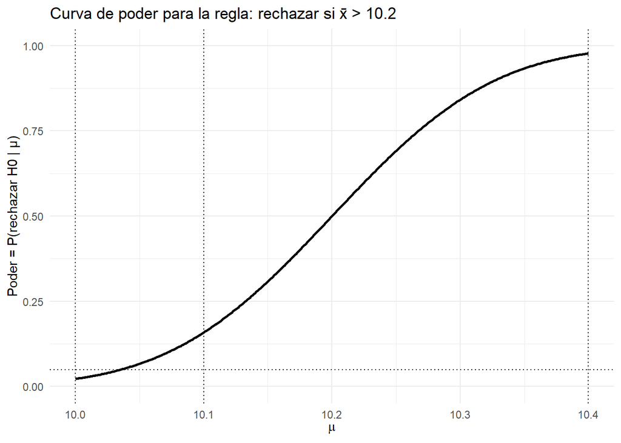

```r
library(ggplot2)

mu0   <- 10
sigma <- 1
n     <- 100
SE    <- sigma / sqrt(n)
corte <- 10.2                 # regla: rechazar si x̄ > 10.2

mu_vals <- seq(10, 10.4, by = 0.001)
poder   <- 1 - pnorm((corte - mu_vals) / SE)
df_pow  <- data.frame(mu = mu_vals, poder = poder)

pwr_mu0  <- 1 - pnorm((corte - 10.0) / SE)   # debe ~ α ≈ 0.0228
pwr_mu01 <- 1 - pnorm((corte - 10.1) / SE)   # ≈ 0.1587
pwr_mu04 <- 1 - pnorm((corte - 10.4) / SE)   # ≈ 0.9773

g_pow <- ggplot(df_pow, aes(mu, poder)) +
  geom_line(linewidth = 1) +
  geom_hline(yintercept = 0.05, linetype = 3) +
  geom_vline(xintercept = c(10.0, 10.1, 10.4), linetype = 3) +
  labs(title = "Curva de poder para la regla: rechazar si x̄ > 10.2",
       y = "Poder = P(rechazar H0 | μ)") +
  scale_x_continuous(name = expression(mu),
                     breaks = c(10.0, 10.1, 10.2, 10.3, 10.4)) +
  coord_cartesian(ylim = c(0, 1)) +
  theme_minimal()

print(g_pow)
```

```r
c(poder_mu0 = pwr_mu0, poder_mu_10_1 = pwr_mu01, poder_mu_10_4 = pwr_mu04)
```

```
##     poder_mu0 poder_mu_10_1 poder_mu_10_4
##    0.02275013    0.15865525    0.97724987
```

El poder de la prueba para la regla “rechazar si $\bar X>10{,}2$” aumenta monótonamente al subir el verdadero promedio $\mu$. Con los parámetros $\sigma=1$, $n=100$ ($SE=0{,}1$), se obtiene: poder($\mu=10{,}0$) $=$ $1-\Phi(2)\approx 0{,}0228$ (coincide con $\alpha$), poder($\mu=10{,}1$) $\approx 0{,}1587$ y poder($\mu=10{,}4$) $\approx 0{,}9773$. Por tanto, cuando la media verdadera está apenas por sobre 10,1 L, la prueba tiene bajo poder, pero a partir de diferencias cercanas a 0,4 L el poder se aproxima a 1.`

##### **Pregunta 4: Considerando un volumen medio de 10 litros, ¿cuántos bidones deberían revisarse para conseguir un poder estadístico de 0,7 y un nivel de significación de 0,05?**

Para responder esta pregunta plantearemos las siguientes hipotesis, las cuales nos ayudaran a fijar el valor nulo y la direccion de la cola:

$$\text{Hipótesis nula}\ (H_0) \text{ : el volumen medio de los bidones es
igual a 10 litros.}\ (\mu = 10)\\
\text{Hipótesis alternativa}\ (H_A) \text{ : el volumen medio de los
bidones es mayor a 10 litros.}\ (\mu > 10)$$

```r
library(pwr)
library(rstatix)

alpha <- 0.05
poder <- 0.7

d <- (mu1 - mu0) / sigma

test <- pwr.t.test(n = NULL, d = d, sig.level = alpha, power = poder, type = "one.sample", alternative = "greater")

n <- ceiling(test$n)
n
```

```
## [1] 472
```

Con el resultado que nos entrego el test utilizado, un nivel de signifiación de 0.05 y un tamaño del efecto 0.1, el tamaño de la muestra que se necesita para conseguir un poder estadístico de 0.7 es de 472 bidones aproximadamente.

##### **Pregunta 5: ¿Alcanzaría esta muestra para detectar la diferencia que la ingeniera sospecha que existe entre las dos máquinas de la planta con al menos las mismas probabilidades de cometer errores?**

La diferencia que la ingeniera a cargo de la planta sospecha consiste en que la máquina antigua llena los bidones a un 90% del cumplimiento del volumen, mientras que la nueva lo hace al 96%. Basado en este análisis, podemos expresar las siguientes hipótesis:

$$\text{Hipótesis nula}\ (H_0) \text{ : el cumplimiento de la máquina
antigua es igual al de la máquina moderna.}\ (p_{\text{antigua}} =
p_{\text{moderna}})\\
\text{Hipótesis alternativa}\ (H_A) \text{ : el cumplimiento de la
máquina antigua es menor al de la máquina moderna.}\ (p_{\text{antigua}}
< p_{\text{moderna}})$$

El planteamiento de las hipótesis deja en evidencia el hecho de que el análisis a realizar consiste en una prueba unilateral de 2 proporciones de igual tamaño (dado que las muestras iniciales también poseen igual tamaño).

Basándonos en los datos de la pregunta anterior, se requiere de una muestra de tamaño 472 para conseguir un poder estadístico de 0.7. Debemos verificar que esta cantidad sea suficiente para poder lograr la verificación de la diferencia que plantea la ingeniera. Por ende, realizaremos una prueba de 2 proporciones con muestras de igual tamaño cuya incógnita sea el tamaño de las muestras, y lo compararemos con el resultado obtenido en la pregunta anterior.

```r
h <- ES.h(0.9, 0.96)

test <- pwr.2p.test(h = h, n = NULL, sig.level = alpha, power = poder, alternative = "less")
n_total <- 2 * ceiling(test$n)
n_total
```

```
## [1] 326
```

Dado que el test nos da el tamaño de cada muestra y estamos trabajando con 2 muestras de igual tamaño, el mínimo tamaño total de la muestra de ambas máquinas para lograr verificar la diferencia que plantea la ingeniera es de 326. Por esto, se concluye que la muestra es suficiente para detectar la diferencia entre máquinas con al menos las mismas probabilidades de cometer errores tipo I y tipo II. Dado que 472 excede significativamente a 326, la muestra no solo alcanza sino que supera los requisitos necesarios para lograr un poder estadístico de 0.7 con un nivel de significación de 0.05.